# Exploratory data analysis on the red wines dataset by Badrinath Thirumalchari

# Multivariate Plots Section

I will focus on features that have high correlations amongst each other and with quality so we can see how two features can impact the quality rating on a plot.

Lets look at how the quality of wine is impacted by citric acid and volatile acidity, because I wanted to see how freshness and unpleasant taste fare into the quality rating. Coordinate transformation might help to look at the data more clearly.

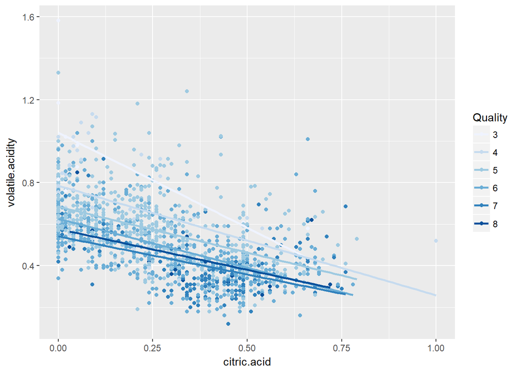

Analyzing the plot above we can see that wines with higher citric acid content and lower volatile acidity have higher ratings, this makes sense.

Alcohol has a pretty strong correlation with density, lets look at how quality fare in that plot.

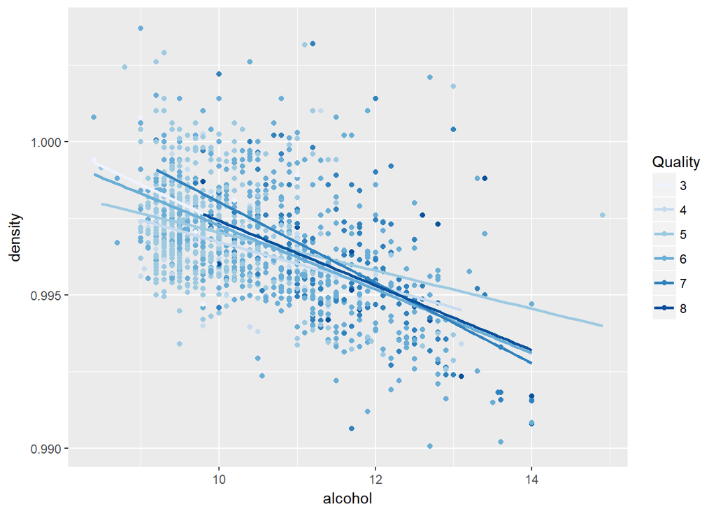

From the plot above we can see that wines with higher quality ratings have a higher alcohol content and lower density.

Lets see how the different acids in the wine correlate with pH, then color the plot based on quality rating.

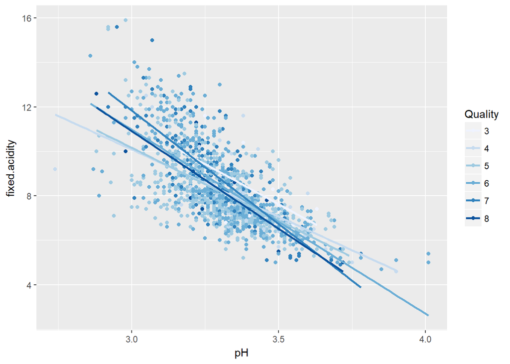

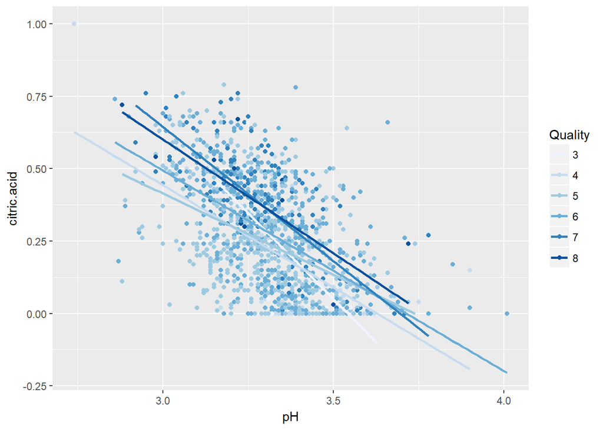

I don’t see a clear pattern emerge in pH vs fixed acidity but the plot if pH vs citric acid is interesting. Generally speaking wines that are rated higher have higher citric acid content and lower pH.

Lets pick the two features that correlate the strongest with quality and then do a multivariate analysis. The features that correlated with quality are alcohol, volatile acidity and sulphates.

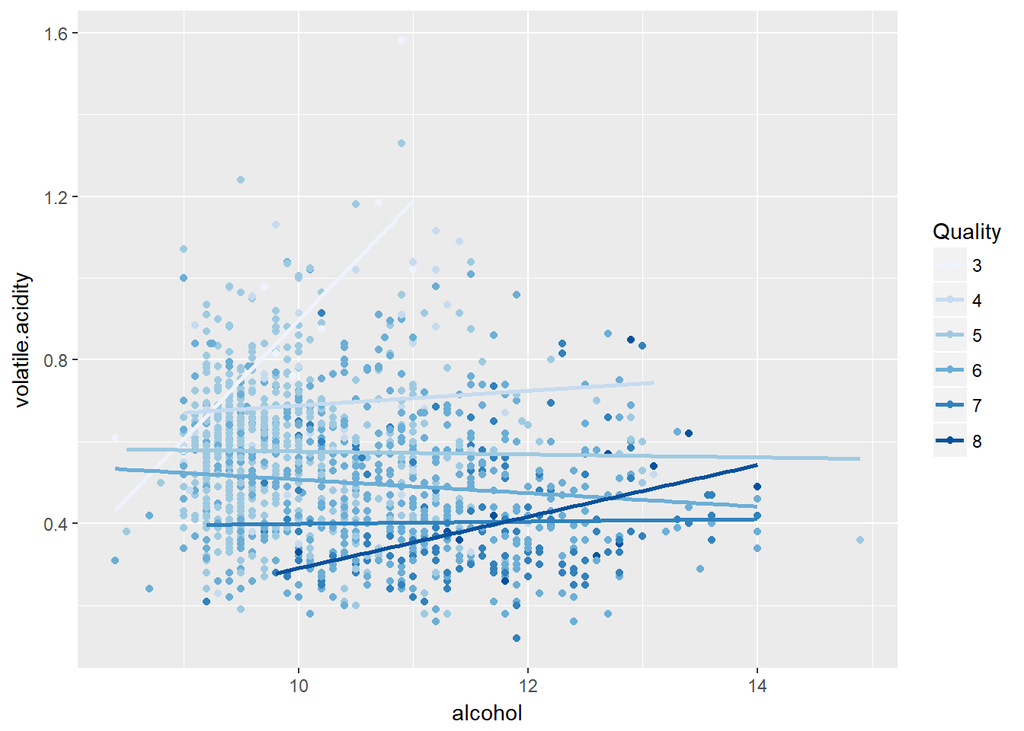

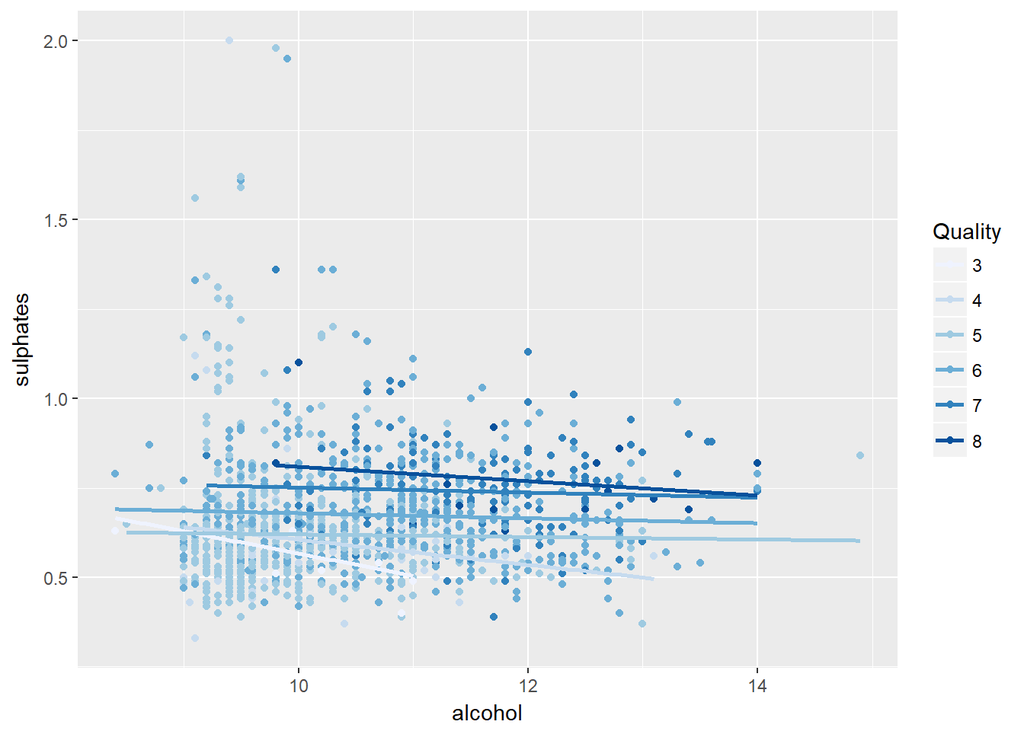

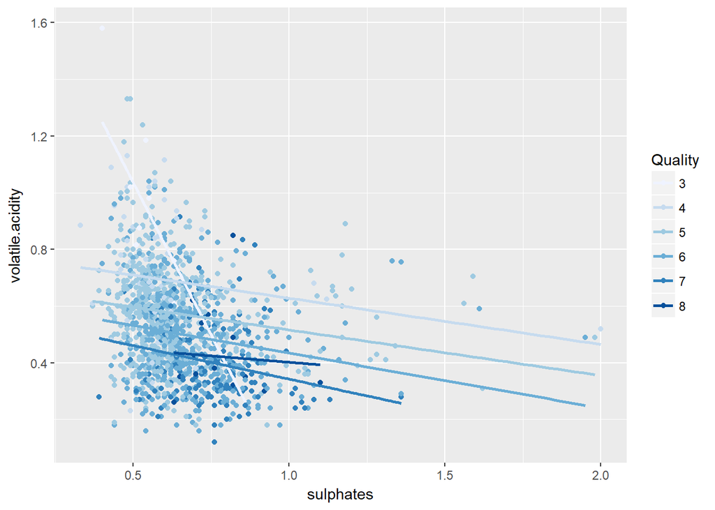

From the above plots we can see some patterns emerge. The features used to create these plots have some correlation with the quality factor we are interested in. From the alcohol vs volatile acidity we can see that wines with higher alcohol and lower volatile acidity are rated higher, alcohol vs sulphates plot we can see that wines with higher alcohol and generally higher sulphate content is rated higher, sulphates vs volatile acidity plot we can see that wines with lower volatile acidity and generally higher sulphate content between a range has higher rating.

# Multivariate Analysis

### Talk about some of the relationships you observed in this part of the investigation. Were there features that strengthened each other in terms of looking at your feature(s) of interest?

I have in detailed explained the relationship I observed below each plot. Performing a multivariate analysis gave me a good perspective of how quality rating is affected by both the features of interest. Most of the features behaved as expected, the features that strengthened each other are effect of alcohol percentage, volatile acidity and citric acid levels in the wine. They seem to be most prominent in determining the quality rating.

### Were there any interesting or surprising interactions between features?

I found the volatile acidity vs citric acid plot very interesting as it clearly shows the importance of these features in deciding the quality rating of the wine.

### OPTIONAL: Did you create any models with your dataset? Discuss the strengths and limitations of your model.

No I did not create any models.

# Final Plots and Summary

### Plot One

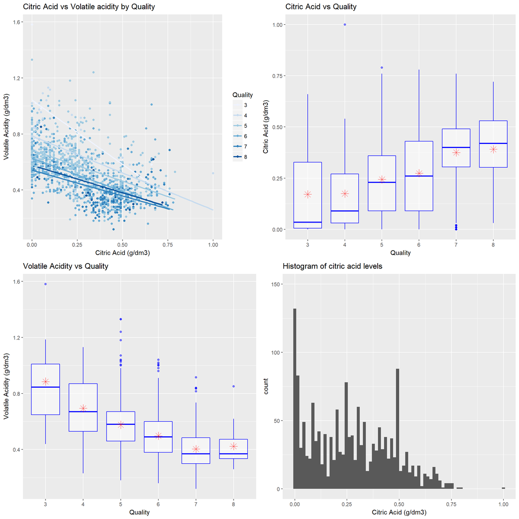

### Plot Two

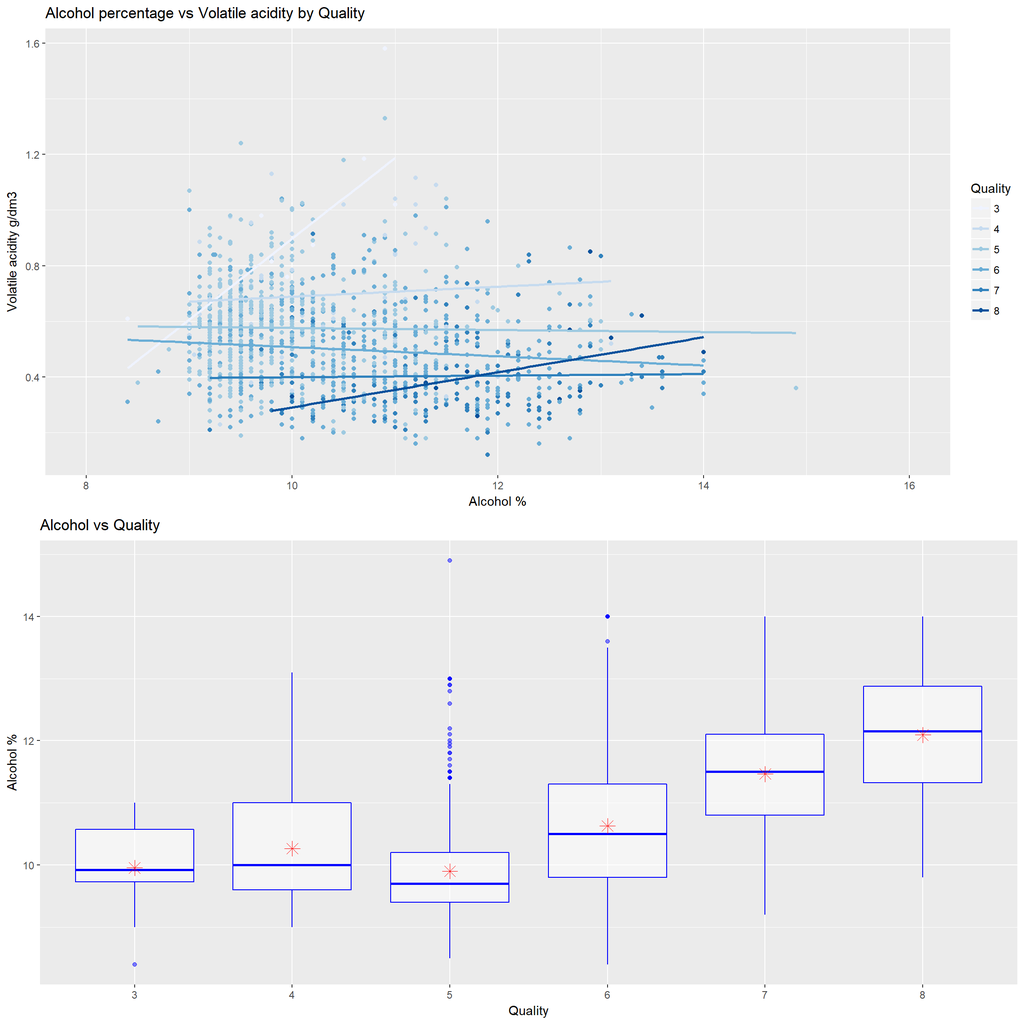

### Description Two

The plot shown above is the relationship between Alcohol vs volatile acidity by quality and alcohol had the highest correlation with quality, I have added the other plot of the features to justify my reasoning. We can see that wines with higher alcohol percentage and lower volatile acidity have higher ratings. The trend we can observe in the box plot is that wines with more alcohol percentage got a better rating and the wines with the highest ratings have the highest mean alcohol percentage and from the lot we can say that wines with a mean alcohol percentage of 11 or more have a rating of 7 and higher. From the first subplot its clear that wines with greater alcohol content and lower volatile acidity get a better rating.

### Plot Three

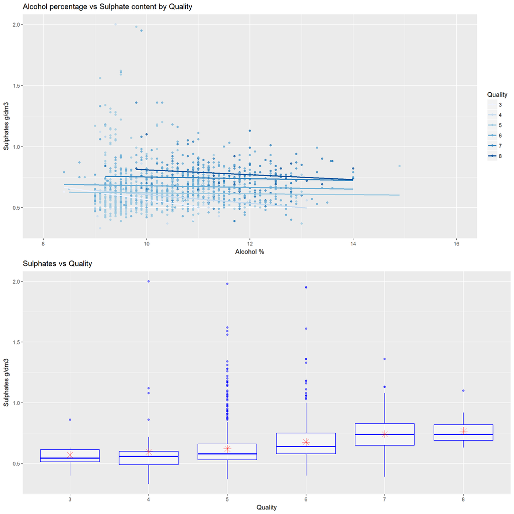

### Description Three

The feature sulphates had a correlation of 0.38 with quality. The first subplot shows a plot of alcohol content vs sulphates by quality. We can clearly see that wines with higher alcohol content and higher sulphate content get a better quality rating. Performing some research online I found that sulphates behaves as a preservative, antioxidant and antibacterial in the wine thus preserving the freshness of the wine. This makes more sense if we look at the box plot of wines, quality rating of 7 and 8 have a median sulphate content of 0.74 g/dm3 greater then the other quality wines.

# Reflection

The data I used to perform EDA consisted of 12 important features of red wines. The entire dataset consisted of 1599 red wines and ratings given to them from a sommelier. My task was to determine what factors are responsible for these quality ratings. I performed extensive EDA on the dataset and found that Alcohol percentage, Volatile acidity content, Sulphates and citric acid had some correlations with the quality rating that the wine received.

The final plots I selected to explain the behavior of the entire dataset were reasonable. We can clearly see how the factors that had some correlation with quality are responsible for the quality rating that the wine was given, neglecting outliers. To summarize this EDA to a reasonable bound, wines with higher alcohol percentage, higher citric acid content, higher sulphate content and lower volatile acidity received a good rating.

The problems I faced while analyzing the dataset is that there are too many variables that correlate with each other and might have played a role in contributing to the quality factor of the wine but I had to decide and investigate more on the features that correlated with the target feature under consideration. After the EDA on the dataset I now to some extent know what factors are responsible for wine quality, I was surprised about the importance of sulphates in red wines to determine the quality.

Future work on the dataset can be to build a machine learning classifier to predict the rating of the wine depending on the features we have discussed in the EDA, this might be useful in investigating the importance of the features themselves.

# References

1. http://www.thekitchn.com/the-truth-about-sulfites-in-wine-myths-of-red-wine-headaches-100878
2. https://s3.amazonaws.com/udacity-hosted-downloads/ud651/wineQualityInfo.txt
3. https://cran.r-project.org/web/packages/corrplot/vignettes/corrplot-intro.html
4. https://www.nceas.ucsb.edu/~frazier/RSpatialGuides/colorPaletteCheatsheet.pdf